# Workflow

#Set up packages and functions

```r
setwd("/u/project/gandalm/kafadare/GandalLab")
output_dir <- ("/u/project/gandalm/kafadare/comb_data/new_data/")
plot_dir <- ("/u/project/gandalm/kafadare/plots/")
source("data_functions.R")
source("analysis_fcts.R")
# List of required packages
#required_packages <- c("magrittr", "genio", "dplyr", "BiocManager", "SummarizedExperiment")
required_packages <- c("magrittr", "dplyr", "data.table", "DESeq2", "WGCNA", "sva", "ggplot2")
# Install or load missing packages
load_install_pkg(required_packages)
```

```
[[1]]
[1] TRUE

[[2]]
[1] TRUE

[[3]]
[1] TRUE

[[4]]
[1] TRUE

[[5]]
[1] TRUE

[[6]]
[1] TRUE

[[7]]
[1] TRUE
```

```r
library(SummarizedExperiment)
```

#Remove low expressed genes from fetal data ##load all fetal data before remoal

##plot gene expression density fetal all

```r
fetal_all_plot_counts <- prep_datExp(fetal_all$counts, gtf_fetal_all) %>% plot_gen_density(., title_str = "Fetal Counts EUR Pre-RM", ylim = c(0, 0.75))
fetal_all_plot_tpm <- prep_datExp(fetal_all$tpm, gtf_fetal_all) %>% plot_gen_density(., title_str = "Fetal Tpm EUR Pre-RM", ylim = c(0, 2.0))
```

##Remove fetal lowly expressed genes

```r
#Remove lowly expressed genes <0.1 25%
fetal_lowrm_counts <- prep_datExp(fetal_all$counts, gtf_fetal_all) %>% rm_low(., fetal_all$tpm, gtf_fetal_all, cutoff = 0.1, percent = 0.25)
fetal_lowrm_tpm <- prep_datExp(fetal_all$tpm, gtf_fetal_all) %>% rm_low(., fetal_all$tpm, gtf_fetal_all, cutoff = 0.1, percent = 0.25)

print(cat("Number of genes before removal:", dim(fetal_all$counts), "Number of genes after removing lowly expressed:",dim(fetal_lowrm_counts), sep='\n'))
fetal_lowrm_counts$genid <- rownames(fetal_lowrm_counts)
fetal_lowrm_tpm$genid <- rownames(fetal_lowrm_tpm)

write.table(fetal_lowrm_counts, file = paste0(output_dir,"fetal_eur_rmlow_counts.tsv"), row.names = F, sep = "\t")
write.table(fetal_lowrm_tpm, file = paste0(output_dir,"fetal_eur_rmlow_tpm.tsv"), row.names = F, sep = "\t")
```

##plot fetal after removing low expressed

```r
#plot both
fetal_rmLow_plot_counts <- prep_datExp(fetal_lowrm_counts, gtf_fetal_all) %>% plot_gen_density(., title_str = "Fetal Counts EUR LowRm", ylim = c(0, 0.75))
fetal_rmLow_plot_tpm <- prep_datExp(fetal_lowrm_tpm, gtf_fetal_all) %>% plot_gen_density(., title_str = "Fetal Tpm EUR LowRM", ylim = c(0, 2.0))
```

#Format adult metadata Do not need to run again, output already saved.

```r
adult_meta_path <- "/u/project/gandalm/kafadare/cov_hcp0_gene.txt"
adult_meta <- fread(adult_meta_path, data.table = F)
adult_meta <- as.data.frame(t(adult_meta))
colnames(adult_meta) <- adult_meta[1, ]
adult_meta <- adult_meta[-1, ]
#add adult data batch column in metadata df
adult_se <- readRDS("/u/home/k/kafadare/project-gandalm/AdultBigBrain_gene_exp_raw_042923.RDS")
batch_index <- match(rownames(adult_meta), colData(adult_se)$names)
adult_meta$study <- colData(adult_se)$batch[batch_index]

#fix subject names
adult_meta$Subject <- rownames(adult_meta) %>% id_format_fix(.)
rownames(adult_meta) <- id_format_fix(rownames(adult_meta))

#filter for EUR ancestry in adult metadata
adult_ancestry <-  read.table("/u/project/gandalm/kafadare/pops.txt", header = F, sep = "\t", col.names = c("id", "ancestry"))
adult_ancestry$id <- id_format_fix(adult_ancestry$id)
missing_ids <- rownames(adult_meta)[!(rownames(adult_meta) %in% adult_ancestry$id)] # 61 ids "missing" from the ancestry file
adult_meta <- adult_meta[(adult_meta$Subject %in% adult_ancestry$id),]
ancestry_index <- match(rownames(adult_meta),adult_ancestry$id)
adult_meta$ancestry <- adult_ancestry$ancestry[ancestry_index]
dim(adult_meta)
adult_meta <- subset(adult_meta, ancestry == "EUR")
dim(adult_meta)

write.table(adult_meta, file = paste0(output_dir,"adult_eur_meta.tsv"), row.names = FALSE, sep = "\t")
```

#Load adult & fetal pre-processed data Load saved fetal files Subset adult for Eur ancestry

```r
colnames(adult$counts) <- id_format_fix(colnames(adult$counts))
#colnames(adult$tpm) <- id_format_fix(colnames(adult$tpm))
ids <- adult$meta$Subject %>% intersect(.,colnames(adult$counts))
adult$counts <- adult$counts[,ids]
#ids <- rownames(adult$meta) %>% intersect(.,colnames(adult$tpm))
#adult$tpm <- adult$tpm[,ids]
#remove gencode version number from the adult dataset gene id
rownames(adult$counts) <- substring(rownames(adult$counts), 1, 15)
#rownames(adult$tpm) <- substring(rownames(adult$tpm), 1, 15)

adult$counts$genid <- rownames(adult$counts)
dim(adult$counts) # 32712 x 1708 (inc genid col)
```

```
[1] 32712  1708
```

```r
dim(fetal$counts) # 30853 x 293 (inc genid col)
```

```
[1] 30853   293
```

##get gene info for all adult EUR genes

```r
gtf_adult_eur <- get_gene_info(adult$counts$genid)
dim(gtf_adult_eur)
dim(adult$counts)
write.table(gtf_adult_eur, file = paste0(output_dir,"gene_info_adult_eur.tsv"), row.names = FALSE, sep = "\t")
```

##plot adult EUR data (lowly expressed already removed)

[figure not shown]

[figure not shown]

#Merge genExp

```r
#get vector of shared genes and subset both fetal and adult data for NON-shared genes
comb_genExp_counts <- merge(adult$counts, fetal$counts, by = "genid",suffixes = c(".a", ".f")) #
#comb_genExp_tpm <- merge(adult$tpm, fetal$tpm, by = "genid",suffixes = c(".a", ".f"))

dim(comb_genExp_counts) #19057 x 2000, inc gen id column - 1999 samples
fetal_only_genes <- fetal$counts[which(!(fetal$counts$genid %in% adult$counts$genid)),]
dim(fetal_only_genes) #11796 x 293, inc gen id column - 292 samples
adult_only_genes <- adult$counts[which(!(adult$counts$genid %in% fetal$counts$genid)),]
dim(adult_only_genes) #13655x1708, inc gen id column - 1707 samples

write.table(comb_genExp_counts, file = paste0(output_dir,"combo_genExp_counts.tsv"), row.names = FALSE, sep = "\t")
#write.table(comb_genExp_tpm, file = paste0(output_dir,"combo_genExp_tpm.tsv"), row.names = FALSE, sep = "\t")
write.table(fetal_only_genes, file = paste0(output_dir,"fetal_only_genExp.tsv"), row.names = FALSE, sep = "\t")
write.table(adult_only_genes, file = paste0(output_dir,"adult_only_genExp.tsv"), row.names = FALSE, sep = "\t")

#get Chr number and start and end codon and strand +/-
gtf_fetal_only <- get_gene_info(fetal_only_genes$genid)
gtf_adult_only <- get_gene_info(adult_only_genes$genid)
gtf_comb <- get_gene_info(comb_genExp_counts$genid)

#save these gtf files too!! ^^^
write.table(gtf_comb, file = paste0(output_dir,"gene_info_comb.tsv"), row.names = FALSE, sep = "\t")
write.table(gtf_fetal_only, file = paste0(output_dir,"gene_info_fetal_only.tsv"), row.names = FALSE, sep = "\t")
write.table(gtf_adult_only, file = paste0(output_dir,"gene_info_adult_only.tsv"), row.names = FALSE, sep = "\t")
```

#Merge meta plot age before merge, after merge plot log transform sex code F - 0 M - 1

```r
#adult metadata cleanup
dim(adult$meta)
```

```
[1] 1707   16
```

```r
colnames(adult$meta)
```

```
 [1] "age"      "sex"      "age2"     "gPC1"     "gPC2"     "gPC3"     "gPC4"     "gPC5"     "gPC6"     "gPC7"     "gPC8"
[12] "gPC9"     "gPC10"    "study"    "Subject"  "ancestry"
```

```r
# adult_gPCs <- adult$meta[,grep("gPC", colnames(adult$meta))]
# adult_gPCs$Subject <- adult$meta$Subject
# write.table(adult_gPCs, file = paste0(output_dir,"adult_gPCs.tsv"), row.names = FALSE, sep = "\t")
adult$meta<- adult$meta[,-grep("gPC", colnames(adult$meta))]
adult$meta$age2 <- NULL
adult$meta$age <- as.numeric(adult$meta$age)
adult$meta$logPcd <- log10(adult$meta$age*365)
sum(is.na(adult$meta$sex))
```

```
[1] 0
```

```r
adult$meta$sex <- as.numeric(adult$meta$sex)

#fetal metadata cleanup
dim(fetal$meta)
```

```
[1] 292   8
```

```r
colnames(fetal$meta) <- c("Subject", "age", "sex", "inferSex", "trimester", "ancestry", "study", "pcw")
fetal$meta$logPcd <- log10(fetal$meta$pcw*7)
sum(is.na(fetal$meta$sex)) #41 without sex
```

```
[1] 41
```

```r
fetal$meta[which(is.na(fetal$meta$sex)),c('sex')] <- fetal$meta[which(is.na(fetal$meta$sex)),c('inferSex')] #total 41 without recorded sex, use inferred sex
sum(is.na(fetal$meta$sex))#all replaced with inferSex
```

```
[1] 0
```

```r
identical(fetal$meta$sex, fetal$meta$inferSex)
```

```
[1] FALSE
```

```r
fetal$meta[which(fetal$meta$sex == "F"),c('sex')] <- "0"
fetal$meta[which(fetal$meta$sex == "M"),c('sex')] <- "1"
fetal$meta$sex <- as.numeric(fetal$meta$sex)

#re-code repeating IDs
f_ids <- which(fetal$meta$Subject %in% adult$meta$Subject)
a_ids <- which(adult$meta$Subject %in% fetal$meta$Subject)

fetal$meta$Subject[f_ids] <- paste0(fetal$meta$Subject[f_ids], ".f")
adult$meta$Subject[a_ids] <- paste0(adult$meta$Subject[a_ids], ".a")

#combine meta data
meta <- merge(fetal$meta, adult$meta, all = T)
```

##age plots

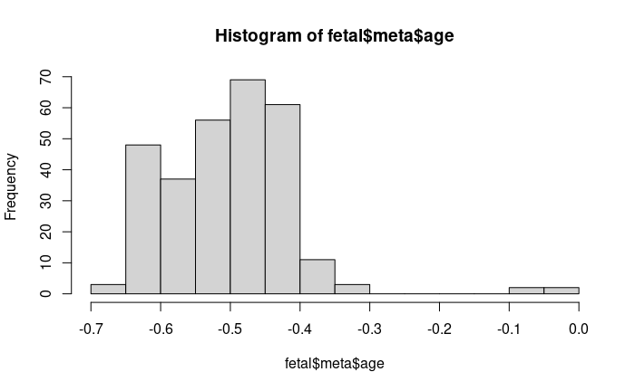

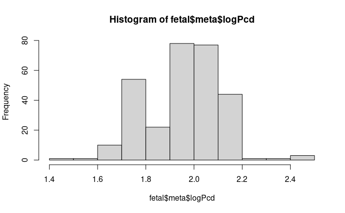

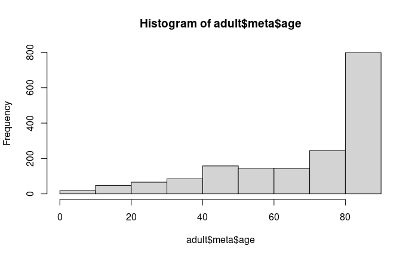

```r
fetal_age <- hist(fetal$meta$age)
fetal_logPcd <- hist(fetal$meta$logPcd)


adult_age <- hist(adult$meta$age)
```

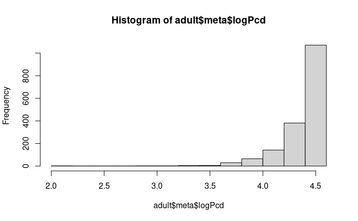

```r
adult_logPcd <- hist(adult$meta$logPcd)
```

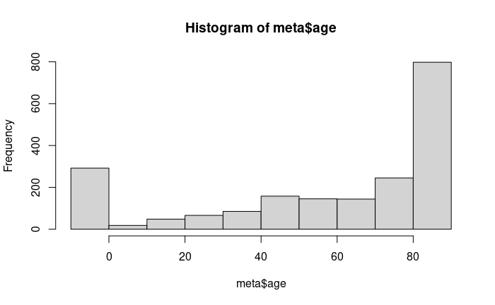

```r
comb_age <- hist(meta$age)
```

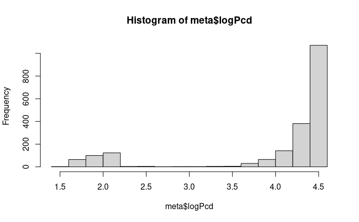

```r
comb_logPcd <- hist(meta$logPcd)
```

```r
summary(meta$age)
```

```
   Min. 1st Qu.  Median    Mean 3rd Qu.    Max.
-0.6904 40.0000 73.0000 59.2307 87.0000 90.0000
```

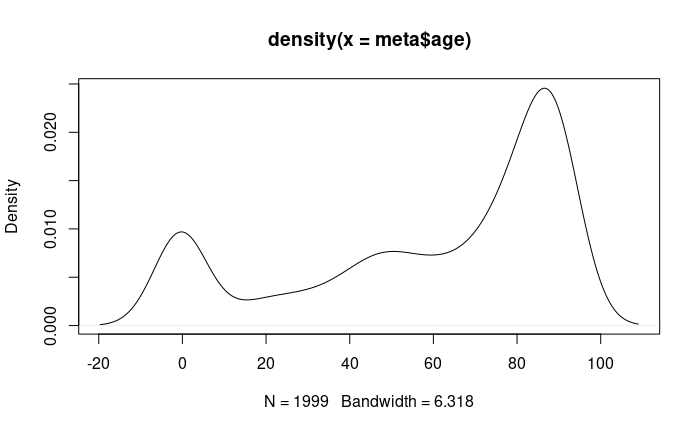

```r
plot(density(meta$age))
```

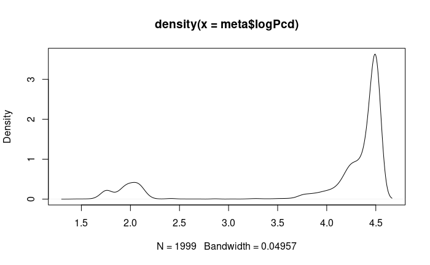

```r
plot(density(meta$logPcd))
```

#Load merged data, plot shared, adult only, fetal only files above saved, can load here

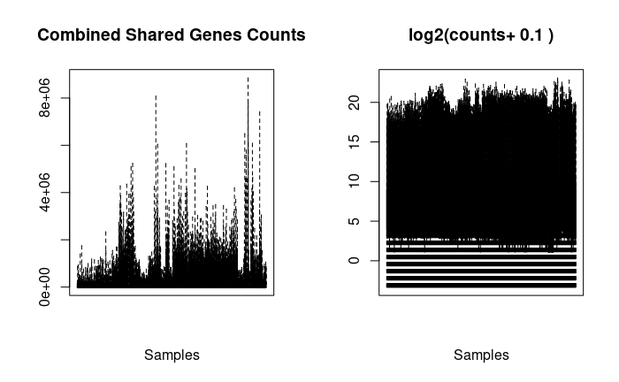

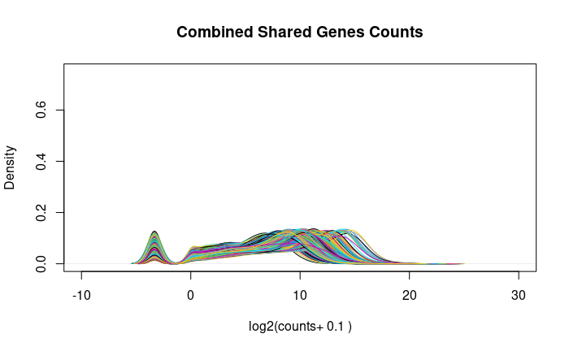

#Normalize & ComBat batch-correct ##Run norm & batch correct - normalize - plot boxplot after norm - batch correct - plot boxplot after combat - plot svd of normalized counts & batch corrected counts

```r
genExp.final <- fread("/u/home/k/kafadare/project-gandalm/comb_data/new_data/processed/counts.norm.noComBat.tsv", data.table = F)
rownames(genExp.final) <- genExp.final$V1
genExp.final$V1 <- NULL
combat_expr <- fread("/u/home/k/kafadare/project-gandalm/comb_data/new_data/processed/counts.batch.processed.tsv", data.table = F)
rownames(combat_expr) <- combat_expr$V1
combat_expr$V1 <- NULL
```

##plots for ComBat

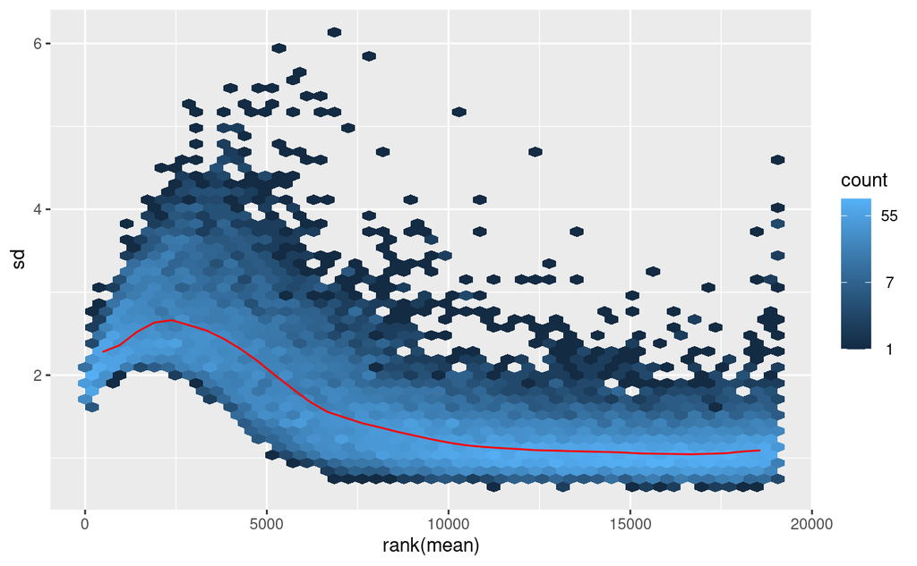

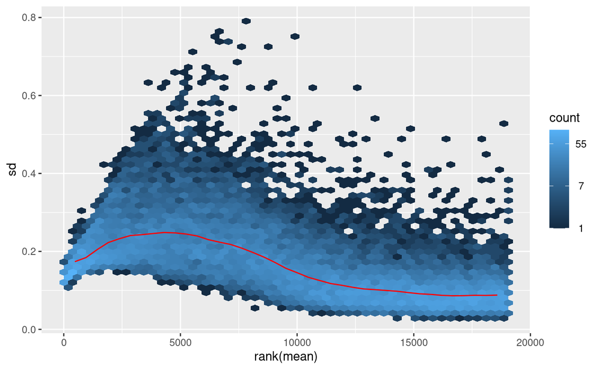

#Covariates ##PCA via PCAforQTLs https://github.com/heatherjzhou/PCAForQTL/blob/master/README.Rmd - get PCA - plot PCA scree plot - get which known covars are explained by PCA - regress out PCs & known covars that remain - plot svd (?) after regressing out #PCs from elbow and # PCs from BE

```r
library(PCAForQTL)
# Load data
datExpr <- fread("/u/home/k/kafadare/project-gandalm/comb_data/new_data/processed/counts.batch.processed.tsv", data.table=F)
rownames(datExpr) <- datExpr$V1
datExpr <- datExpr[,-1]
meta <- fread("/u/home/k/kafadare/project-gandalm/comb_data/new_data/combined_meta.tsv", header = T, data.table = F)

#datExpr <- combat_expr
#rm(combat_expr)

#remove meta subjects that aren't in the final sample
meta <- meta[which(meta$Subject %in% colnames(datExpr)),]
rownames(meta) <- meta$Subject


#std_datExpr <- standardize(t(datExpr))
expr<-t(datExpr)
meta <- meta %>% arrange(match(rownames(meta),rownames(expr)))
dim(expr) # 1982 x 19057
#write.table(meta, paste0(output_dir,"processed/", "meta_outliers_removed.tsv"), quote = F, row.names = F, col.names = T, sep = "\t")
meta <- meta[,-1]

# Generate covariates - PCA
prcompResult<-prcomp(expr,center=T,scale.=T) #This should take less than a minute.
PCs <-prcompResult$x

#inspect
importanceTable<-summary(prcompResult)$importance
PVEs<-importanceTable[2,]
sum(PVEs) #Theoretically, this should be 1.
plot(PVEs,xlab="PC index", ylab="PVE")

##choosing # of PCs

#`runElbow()` implements an automatic elbow detection method (based on distance to the diagonal line). In our experience, the number of PCs chosen using this method **tends to match the visual elbow point reasonably well**. To run this function, simply input the previously obtained `prcompResult`. This method selects $K=12$ for our example data.
resultRunElbow<-PCAForQTL::runElbow(prcompResult=prcompResult)
print(resultRunElbow) #36

#`runBE()` implements the BE algorithm, a permutation-based approach for choosing $K$ in PCA. Intuitively, the BE algorithm retains PCs that explain more variance in the data than by random chance and discards those that do not. In our experience, the number of PCs chosen via BE **tends to signal an upper bound of the reasonable number of PCs to choose**. To run this function, we need to input the data matrix (must be observation by feature) and may optionally specify `B`, the number of permutations (default is 20), and `alpha`, the significance level (default is $0.05$). We may also specify `mc.cores` to change how many cores are used for parallel computing (default is `B` or the number of available cores minus 1, whichever is smaller). For reproducibility, Linux and Mac users must change the random number generator (RNG) type (unless `mc.cores` is 1) and set the seed. On the other hand, Windows users must set `mc.cores=1` to avoid error and set the seed for reproducibility (no need to change the RNG type).

RNGkind("L'Ecuyer-CMRG")
set.seed(1)
resultRunBE<-PCAForQTL::runBE(expr,B=20,alpha=0.05)
print(resultRunBE$numOfPCsChosen) #92

#Save topPCs given BE
PCsTop<-PCs[,1:K_BE] #1982*92
write.table(PCsTop, paste0(output_dir,dim(PCsTop)[2], "PCs.txt"), quote = F, row.names = T, col.names = T, sep = "\t")

#visualize number of PCs chosen
K_elbow<-resultRunElbow #36
K_BE<-resultRunBE$numOfPCsChosen #92
#K_GTEx<-60 #GTEx uses 60 PEER factors, and they are almost identical to the top 60 PCs.
PCAForQTL::makeScreePlot(prcompResult,labels=c("Elbow","BE"),values=c(K_elbow,K_BE),
                         titleText="PCA QTL")

ggplot2::ggsave(paste0(plot_dir, "PCAQTL.jpg"),width=16,height=11,unit="cm")
```

##get genotype PCs as covariates from fetal, HSB194, 1874, Br2416 do not have genotype data but do have genExp & metadata — were removed as ‘outliers’ in the fetal .vcf file, but not detected as ‘outliers’ in the merged sample. Since genotype was merged from the outlier removed .vcf file, there is this discrepancy from adult CMC_MSSM_025, does not appear in the adult vcf file

```r
write.table(known_covs[,c("genoID")], paste0(output_dir,"processed/", "genoID_1968.txt"), quote = F, row.names = F, col.names = F, sep = "\t")
```

```
Error: object 'known_covs' not found
```

##combine covariates

```r
model.matrix(~0+., data=PCs_study) %>%
  cor(use="pairwise.complete.obs") %>%
  ggcorrplot(show.diag=FALSE, type="lower", lab=TRUE, lab_size=2)
```

```
Error: cannot allocate vector of size 740.1 Mb
```

##correlations between covariates

```r
corr <- cor(t(X))
# Filter the correlation matrix for correlations > 0.5
# Find variables with at least one correlation > 0.5
# Find variables with at least one correlation > 0.5
selected_vars <- colnames(corr)[apply(abs(corr) > 0.5, 1, function(x) sum(x) > 1)]

# Filter the correlation matrix for selected variables
corr_high <- corr[which(rownames(corr) %in% selected_vars), selected_vars]

# Create a heatmap of the filtered correlation matrix
ggplot(data = reshape2::melt(corr_high), aes(Var1, Var2, fill = value)) +
  geom_tile() +
  scale_fill_gradient(low = "white", high = "blue", limits = c(0, 1)) +
  labs(title = "Correlation Heatmap (Correlations > 0.5)")
```

#Regress out the Covariates ##Regress out cov with variables as colnames, sample ids as rownames datExpr with sample id as colnames, gene id as rownames

```r
identical(rownames(covnoPC), colnames(datExpr))#TRUE
```

```
[1] TRUE
```

##visualize

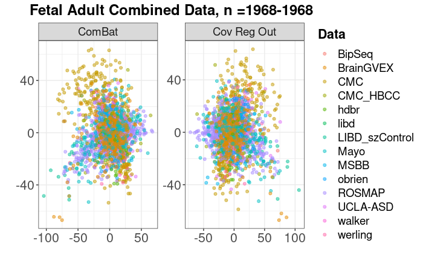

#Prep genExp format for MESC

```r
datExp <- fread("/u/project/gandalm/kafadare/comb_data/new_data/processed/genExp_covRegOut.tsv", data.table = F)
ids <- read.table("/u/project/gandalm/kafadare/comb_data/new_data/processed/genoID_IID_1968.txt", header = T)
gtf <- fread("/u/project/gandalm/kafadare/comb_data/new_data/gene_info_comb.tsv", data.table = F)
index <- match(colnames(datExp[,2:ncol(datExp)]), ids$IID)
colnames(datExp) <- c("GENE", ids$genoID[index])
datExp <- merge(datExp, gtf, by.x = "GENE", by.y = "genid", all = TRUE)
datExp <- datExp[, c(1, ncol(datExp)-3, ncol(datExp)-2, ncol(datExp)-1, ncol(datExp), 2:(ncol(datExp)-4))]

# special note! strand; 0/1-based conversion
for (i in 1:dim(datExp)[1]){
    if (datExp[i,4] == "+") {
        gtf_start=datExp[i,2]
      datExp[i,2]=gtf_start-1
        datExp[i,3]=gtf_start
    }
    else if (datExp[i,4] == "-") {
        gtf_end=datExp[i,3]
        datExp[i,2]=gtf_end-1
        datExp[i,3]=gtf_end
    }
}

datExp <- datExp[order(datExp$Chr, datExp$start),] %>% select(., -c("end","strand"))

colnames(datExp)[1:3] <- c("GENE", "CHR", "GENE_COORD")

write.table(datExp, paste0(output_dir,"processed/","genExp_regOut_mesc_format.bed"), quote=F, sep="\t", row.names=F, col.names=T)
```